```python
%matplotlib inline
```

# 使用Keras构建一个简单的神经网络

作者：Xavier Snelgrove  
原文：[keras-mnist-tutorial](https://github.com/wxs/keras-mnist-tutorial/blob/master/MNIST%20in%20Keras.ipynb)

这是个简单的入门教程，向你演示如何使用Keras构建神经网络来识别手写数字。（在多伦多大学用作入门教程）。它基于Keras源码里example目录下的mnist_mlp.py

# 安装依赖

（在Mac/Linux下）首先，你需要安装最新版的Python，加上这些包：**keras, numpy, matplotlib and jupyter**。

### 安装最新Python（译者注：一般使用系统自带的就行）

如果你没有安装Python，我建议你使用[Homebrew](http://brew.sh/)安装（Mac用户）: `brew install python`

### 配置一个虚拟环境

你当然可以全局安装依赖，但我建议使用`virtualenv`创建隔离的虚拟环境。首先你需要安装pip(python包管理工具)：

`easy_install pip`

如果发生权限错误，你需要使用`sudo`来安装:`sudo easy_install pip`

接着安装`virtualenv`:`pip install virtualenv`

使用`cd ~`进入home目录并创建虚拟环境,将其命名为kerasenv：`virtualenv kerasenv`

切换到虚拟环境：`source kerasenv/bin/activate`

现在可以开始安装其他依赖：`pip install numpy jupyter keras matplotlib`

### 打开一个notebook

万事俱备，让我们打开一个基于web的python环境：`ipython notebook`

[figure not shown]

你现在可以在浏览器里跑Python代码啦

### 创建神经网络

我们先把依赖导入：

```python
import numpy as np
import matplotlib.pyplot as plt
plt.rcParams['figure.figsize'] = (7,7) # Make the figures a bit bigger（使数字更大些）

from keras.datasets import mnist
from keras.models import Sequential
from keras.layers.core import Dense, Dropout, Activation
from keras.utils import np_utils

#  Visualization
#from keras import callbacks
#remote = callbacks.RemoteMonitor(root='http://localhost:9000')
```

```
Using Theano backend.
```

### 载入训练数据集

```python
nb_classes = 10

# the data, shuffled and split between tran and test sets （将数据集混排、切分为训练数据集和测试数据集）
(X_train, y_train), (X_test, y_test) = mnist.load_data() # 译者注：初次将默认下载到目录：~/.keras/datasets
print("X_train original shape", X_train.shape)
print("y_train original shape", y_train.shape)
```

```
X_train original shape (60000, 28, 28)
y_train original shape (60000,)
```

让我们看看训练集中的一些例子

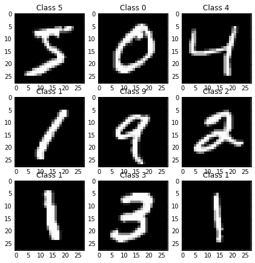

```python
for i in range(9):
    plt.subplot(3,3,i+1)
    plt.imshow(X_train[i], cmap='gray', interpolation='none') # 我的github用了主图，可能反色
    plt.title("Class {}".format(y_train[i]))
```

### 将数据格式化（以便于训练）

我们的神经网络的每条训练数据需要是一个向量（扁平），因此我们需要将每个28x28的输入图片变形为一个784维的向量（译者：形如一维？只是有784个特征）。 我们同时把输入值的变动范围调整为`[0-1]`，而不是 `[0-255]`

```python
X_train = X_train.reshape(60000, 784)
X_test = X_test.reshape(10000, 784)
X_train = X_train.astype('float32')
X_test = X_test.astype('float32')
X_train /= 255
X_test /= 255
print("Training matrix shape", X_train.shape)
print("Testing matrix shape", X_test.shape)
# 译者注：可以自行观察样本：X_train[1]
```

```
Training matrix shape (60000, 784)
Testing matrix shape (10000, 784)
```

将目标矩阵改为one-hot格式，形如：

[output not shown]

```python
Y_train = np_utils.to_categorical(y_train, nb_classes)
Y_test = np_utils.to_categorical(y_test, nb_classes)
```

# 构建神经网络

我们将构建一个建议的3层的全连接网络

[figure not shown]

```python
model = Sequential()
model.add(Dense(512, input_shape=(784,)))
model.add(Activation('relu')) # An "activation" is just a non-linear function applied to the output
                              # of the layer above. Here, with a "rectified linear unit",
                              # we clamp all values below 0 to 0.

model.add(Dropout(0.2))   # Dropout helps protect the model from memorizing or "overfitting" the training data, #防止过拟合
model.add(Dense(512))
model.add(Activation('relu'))
model.add(Dropout(0.2))
model.add(Dense(10))
model.add(Activation('softmax')) # This special "softmax" activation among other things,
                                 # ensures the output is a valid probaility distribution, that is
                                 # that its values are all non-negative and sum to 1.
```

# 编译模型

Keras构建在Theano之上（现在也支持TensorFlow），两者都允许你用Python定义计算图，之后它们将在CPU 或者 GPU上高校运行，而没有python解释器的开销

我们的预期是十类数字概率分布（例如，该图片80%的可能性是3，10%的可能性是8，5%的可能性是2，等等），我们的目标是正确分类的概率是100%，其他为0。 交叉熵是一种度量的预期分布与目标分布差异的手段。更多细节参考:[Cross entropy](https://en.wikipedia.org/wiki/Cross_entropy)

优化器决定了模型的学习速度，以及遇到`stuck`和"blowing up"时如何应对。我们在此不谈论太多细节，"adam"优化器通常是个好的选择

### 参考（译者注）

http://keras-cn.readthedocs.io/en/latest/getting_started/sequential_model/ http://keras-cn.readthedocs.io/en/latest/models/sequential/#sequential_2 http://keras-cn.readthedocs.io/en/latest/other/objectives/

```python
model.compile(loss='categorical_crossentropy',metrics=["accuracy"], optimizer='adam') # 译者注：教程里没有metrics=["accuracy"],版本问题
```

## 训练模型！

这是有趣的一部分：你把此前加载的训练数据喂给模型，它将学会分类：

```python
model.fit(X_train, Y_train,
          batch_size=128, nb_epoch=4,
          verbose=1,
          validation_data=(X_test, Y_test))  #,callbacks=[remote])
```

```
Train on 60000 samples, validate on 10000 samples
```

```
<keras.callbacks.History at 0x111497828>
```

# 最后，评估性能

```python
score = model.evaluate(X_test, Y_test,verbose=0)
print('Test score:', score[0])
print('Test accuracy:', score[1])
```

```
Test score: 0.0822264340611
Test accuracy: 0.9759
```

### 检查输出

检查输出并确保结果合理是一种好习惯。我们来看看一些分类正确的例子，也看看分类错误的一些例子：

```python
# The predict_classes function outputs the highest probability class
# according to the trained classifier for each input example.
predicted_classes = model.predict_classes(X_test)

# Check which items we got right / wrong
correct_indices = np.nonzero(predicted_classes == y_test)[0]
incorrect_indices = np.nonzero(predicted_classes != y_test)[0]
```

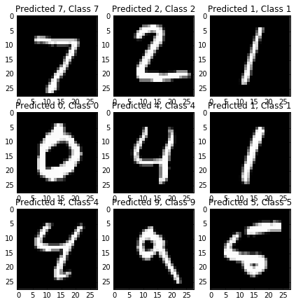

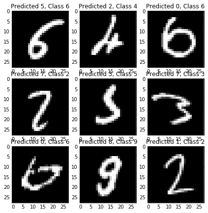

```python
plt.figure()
for i, correct in enumerate(correct_indices[:9]):
    plt.subplot(3,3,i+1)
    plt.imshow(X_test[correct].reshape(28,28), cmap='gray', interpolation='none')
    plt.title("Predicted {}, Class {}".format(predicted_classes[correct], y_test[correct]))

plt.figure()
for i, incorrect in enumerate(incorrect_indices[:9]):
    plt.subplot(3,3,i+1)
    plt.imshow(X_test[incorrect].reshape(28,28), cmap='gray', interpolation='none')
    plt.title("Predicted {}, Class {}".format(predicted_classes[incorrect], y_test[incorrect]))
```

# 结语

在Keras的[主页](http://keras.io)有许多优秀的例子，他们的源码在https://github.com/fchollet/keras